# menu_report.Rmd

2022-10-06

## Assignment-2-Jezahmoud

We start by loading packages, data, and making some basic changes to make the column names easier to read.

## Data

```r
# Loading dataset
Data = read.csv("~/Documents/dsi_2022-02/individual-assignment-2-Jezahmoud/data/menu.csv", header=T)

# Cleaning the columns names
Clean_names <- gsub(pattern = "*....Daily.Value.", replacement=".DV", names(Data))
names(Data) <- Clean_names

datatable(Data,options = list(searching = FALSE,pageLength = 5,lengthMenu = c(5, 10, 15, 20), scrollX = T),
          caption = 'Table 1: Mcdonalds/nutrition-facts dataset.')
```

|  | Category | Item | Serving.Size | Calories | Calories.from.Fat | Total.Fat | Total.Fat.DV | Saturated.Fat | Saturated.Fat.DV | Trans.Fat | Cholesterol | Cholesterol.DV | Sodium | Sodium.DV | Carbohydrates | Carbohydrates.DV | Dietary.Fiber | Dietary.Fiber.DV | Sugars | Protein | Vitamin.A.DV | Vitamin.C.DV | Calcium.DV | Iron.DV |
| --- | --- | --- | --- | --- | --- | --- | --- | --- | --- | --- | --- | --- | --- | --- | --- | --- | --- | --- | --- | --- | --- | --- | --- | --- |
| 1 | Breakfast | Egg McMuffin | 4.8 oz (136 g) | 300 | 120 | 13 | 20 | 5 | 25 | 0 | 260 | 87 | 750 | 31 | 31 | 10 | 4 | 17 | 3 | 17 | 10 | 0 | 25 | 15 |
| 2 | Breakfast | Egg White Delight | 4.8 oz (135 g) | 250 | 70 | 8 | 12 | 3 | 15 | 0 | 25 | 8 | 770 | 32 | 30 | 10 | 4 | 17 | 3 | 18 | 6 | 0 | 25 | 8 |
| 3 | Breakfast | Sausage McMuffin | 3.9 oz (111 g) | 370 | 200 | 23 | 35 | 8 | 42 | 0 | 45 | 15 | 780 | 33 | 29 | 10 | 4 | 17 | 2 | 14 | 8 | 0 | 25 | 10 |
| 4 | Breakfast | Sausage McMuffin with Egg | 5.7 oz (161 g) | 450 | 250 | 28 | 43 | 10 | 52 | 0 | 285 | 95 | 860 | 36 | 30 | 10 | 4 | 17 | 2 | 21 | 15 | 0 | 30 | 15 |
| 5 | Breakfast | Sausage McMuffin with Egg Whites | 5.7 oz (161 g) | 400 | 210 | 23 | 35 | 8 | 42 | 0 | 50 | 16 | 880 | 37 | 30 | 10 | 4 | 17 | 2 | 21 | 6 | 0 | 25 | 10 |
| 6 | Breakfast | Steak &amp; Egg McMuffin | 6.5 oz (185 g) | 430 | 210 | 23 | 36 | 9 | 46 | 1 | 300 | 100 | 960 | 40 | 31 | 10 | 4 | 18 | 3 | 26 | 15 | 2 | 30 | 20 |
| 7 | Breakfast | Bacon, Egg &amp; Cheese Biscuit (Regular Biscuit) | 5.3 oz (150 g) | 460 | 230 | 26 | 40 | 13 | 65 | 0 | 250 | 83 | 1300 | 54 | 38 | 13 | 2 | 7 | 3 | 19 | 10 | 8 | 15 | 15 |
| 8 | Breakfast | Bacon, Egg &amp; Cheese Biscuit (Large Biscuit) | 5.8 oz (164 g) | 520 | 270 | 30 | 47 | 14 | 68 | 0 | 250 | 83 | 1410 | 59 | 43 | 14 | 3 | 12 | 4 | 19 | 15 | 8 | 20 | 20 |
| 9 | Breakfast | Bacon, Egg &amp; Cheese Biscuit with Egg Whites (Regular Biscuit) | 5.4 oz (153 g) | 410 | 180 | 20 | 32 | 11 | 56 | 0 | 35 | 11 | 1300 | 54 | 36 | 12 | 2 | 7 | 3 | 20 | 2 | 8 | 15 | 10 |
| 10 | Breakfast | Bacon, Egg &amp; Cheese Biscuit with Egg Whites (Large Biscuit) | 5.9 oz (167 g) | 470 | 220 | 25 | 38 | 12 | 59 | 0 | 35 | 11 | 1420 | 59 | 42 | 14 | 3 | 12 | 4 | 20 | 6 | 8 | 15 | 15 |

[output cut: 250 more lines]

We want to look at how serving size relates to different nutritional values. However, serving size is recorded it means ounces and grammes are mixed together in the same column. We turn it into a single number variable called food.g for solid food and millilitres for liquid food.

```r
# Choose the fields that have the strings "fl oz" and "carton"
drinks.oz <- Data[str_detect(Data$Serving.Size, " fl oz.*"),]
drinks.ml <- Data[str_detect(Data$Serving.Size, 'carton'),]

#Convert the ounces to millilitres
#values are rounded to zero decimal places
drinks.oz$Serving.Size <-
  round(as.numeric(gsub(" fl oz.*", "", drinks.oz$Serving.Size))*29.5735,0)
drinks.ml$Serving.Size <-
  round(as.numeric(gsub(".*\\((.*)\\ ml).*", "\\1", drinks.ml$Serving.Size)),0)

# Choose fields that contain "g" string
# values are rounded to zero decimal places
food.g <- Data[str_detect(Data$Serving.Size, 'g'),]
food.g$Serving.Size <-
  round(as.numeric(gsub(".*\\((.*)\\ g).*", "\\1", food.g$Serving.Size)),0)

# Merge the rows of all those data tables into a single data table.
# Make a new column labelled "Type" and the values to be "drink" or "meal."
Data2 <- rbind(drinks.oz,drinks.ml)
Data2$Type <- rep("drinks.ml", nrow(Data2))
food.g$Type <- rep("food.g", nrow(food.g))
Data2 <- rbind(Data2,food.g)
```

## Exploratory Data Analysis

How each type of food is spread out. When it comes to menu options, coffee and tea are by far the most popular.

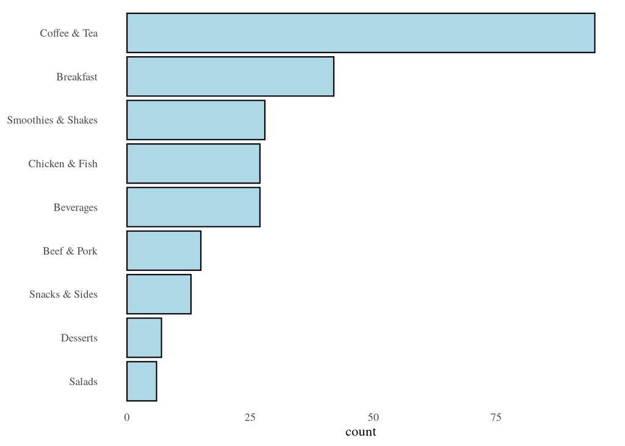

```r
# Food categories
options(repr.plot.height=3, repr.plot.width=6)
ggplot(Data2) +
  geom_bar(aes(x = reorder(Category, table(Category)[Category])), fill = "lightblue",color="black") +
  coord_flip() +
  theme_tufte(ticks=F) +
  labs(x = NULL)
```

Calorie distribution as shown by a histogram with density line. Around 300 is where we see the highest concentration of Caloric values.

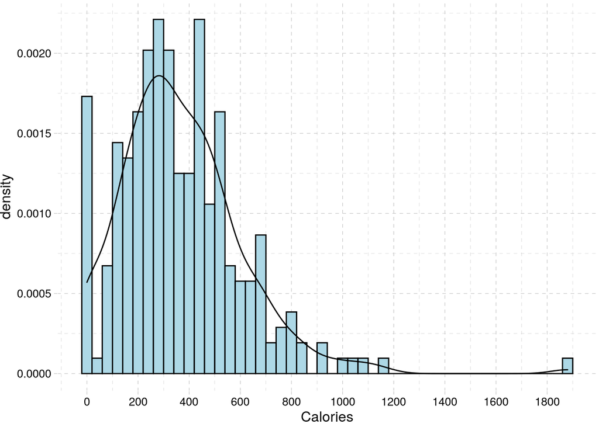

```r
# Exploring calories
options(repr.plot.height=3, repr.plot.width=6)
ggplot(Data2, aes(x = Calories)) +
  geom_histogram(aes(y = ..density..), fill = "lightblue", binwidth = 40, color="black") +
  geom_density() +
  scale_x_continuous(breaks = seq(min(Data$Calories), max(Data$Calories), by = 200)) +
  theme_pander()
```

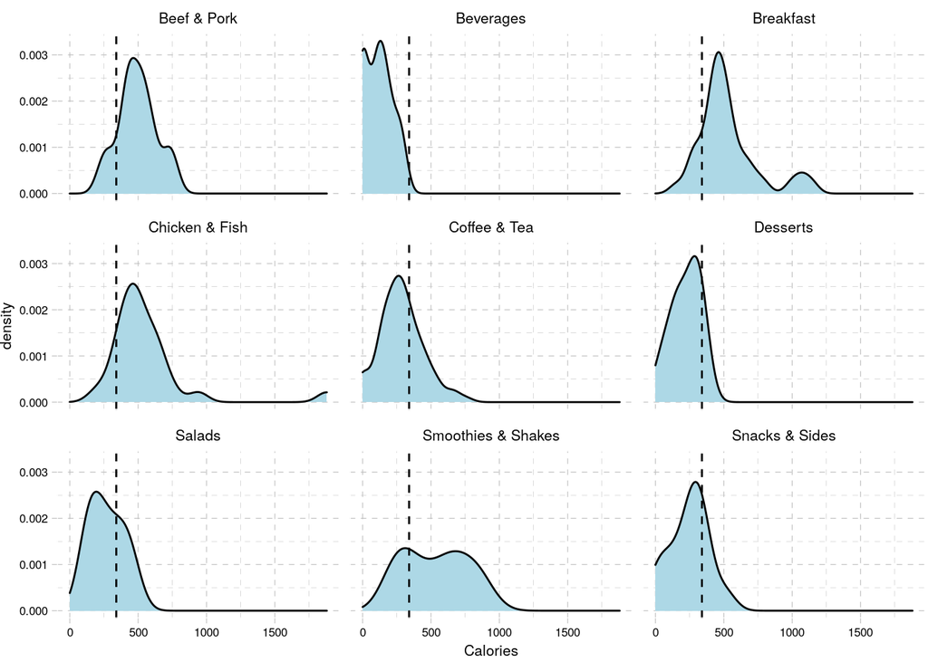

```r
#Calories by category
options(repr.plot.height=4, repr.plot.width=6)
ggplot(Data2, aes(x = Calories)) +
  geom_density(fill="lightblue") +
  facet_wrap( ~ Category) +
  geom_vline(aes(xintercept = median(Calories)), linetype = 2) +
  theme_pander(base_size=8)
```

The number of calories in each type of food is shown in a box plot. As you might have guessed from the density plots above, the most calorically dense food groups are (a) chicken and fish, (b) smoothies and shakes, (c) breakfast, and (d) beef and pork. We can now see in the box plot that the Chicken & Fish group has a huge outlier in terms of calories.

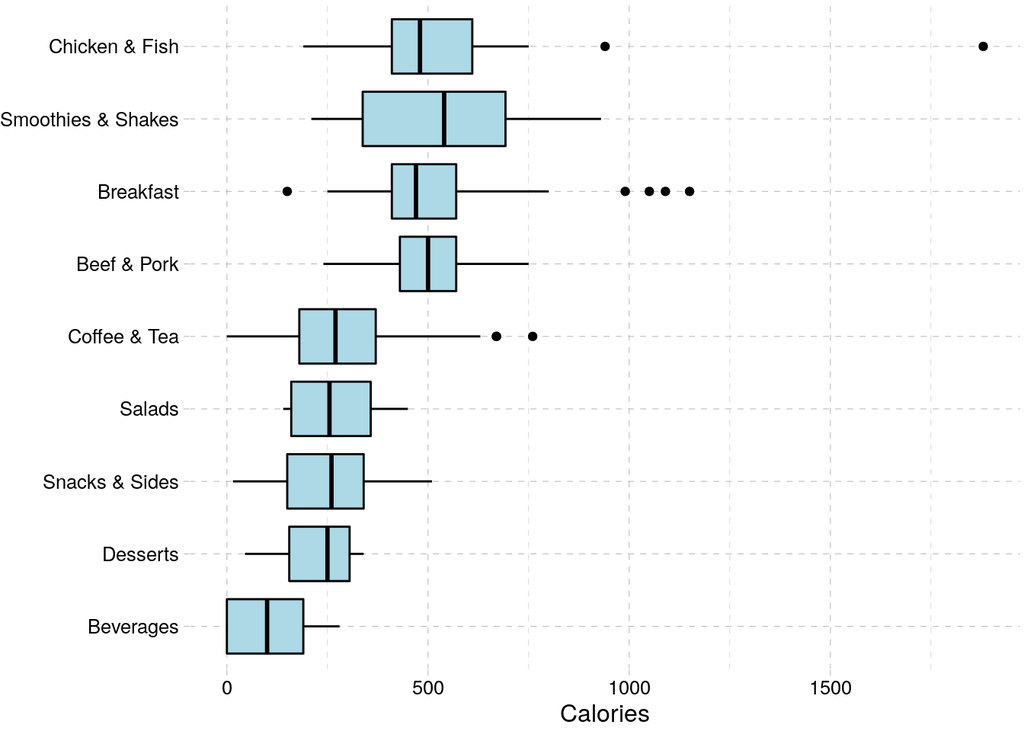

```r
#Calories by category
options(repr.plot.height=3, repr.plot.width=6)
ggplot(Data2, aes(x = reorder(Category, Calories), y = Calories)) +
  geom_boxplot(color="black",fill="lightblue") +
  coord_flip() +
  theme_pander() +
  labs(x = NULL)
```

## Conclusion

A brief exploratory data analysis has been done for the data set. The time limitation restricted us to performing more invistagation. But we were able to use some useful information about the data set we were looking at.